# Categorical Data Analysis

## Packages

```r
install.packages(c("UpSetR", "ggmosaic", "vcd",
                   "rgl", "vcdExtra", "DescTools"))
```

Categorical data is common. You will see it in just about any domain that you would want to explore. It does, however, have its own unique set of challenges. For example, we cannot get means for categorical variables and we cannot get correlations between two categorical values.

What is important, though, is what we can do with categorical data.

Throughout most document packages are denoted by purple (ggplot2) and functions are orange (ggplot). Clicking on the purple words won’t do anything 🤣

## As A Data Type

Our previous visualization work leads us nicely up to this point. Recall one of our previous visualizations:

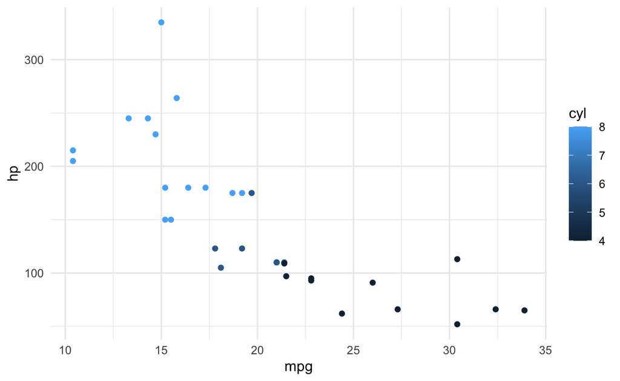

```r
library(ggplot2)

ggplot(mtcars, aes(mpg, hp, color = cyl)) +
  geom_point() +
  theme_minimal()
```

Nothing really looks amiss here, right? We have our x and y axes and we have the points colored by cylinder. But…what do you know about cylinders in a vehicle? I am not a mechanic, but I am pretty sure that there are not many 8.5 cylinder cars on the road.

This gets us into an area where we need to make a decision about how to treat such a variable. There is no doubt that the number of cylinders a car has is indeed a number, but would it make sense to treat that variable as categorical here? For this visualization, I think it makes a big difference.

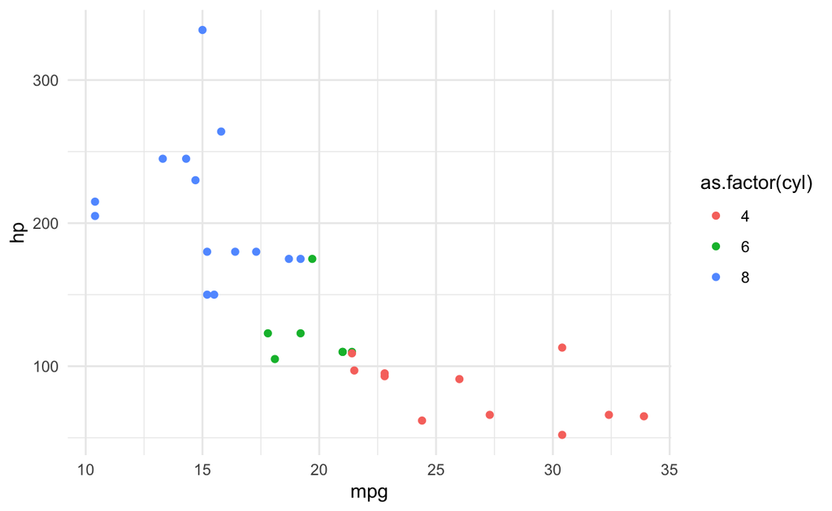

```r
ggplot(mtcars, aes(mpg, hp, color = as.factor(cyl))) +
  geom_point() +
  theme_minimal()
```

Instead of a color gradient, we have a nice discreet color scheme that makes it very clear what we are looking at with regard to our cylinders (it also gives a very clear indication of the nature of that variable within our data).

In the second ggplot chunk, you might have noticed that we converted our cyl variable to a factor with the as.factor function. This function, and the related as.numeric and as.character, serve the same purpose. You will often see data like the following:

```r
factorExample <- data.frame(numeric = 1:10,
                           factor = factor(seq(1, 5.5, by = .5)))

factorExample
```

```
   numeric factor
1        1      1
2        2    1.5
3        3      2
4        4    2.5
5        5      3
6        6    3.5
7        7      4
8        8    4.5
9        9      5
10      10    5.5
```

Great! The data looks perfect the way we see it. You might be interested in looking at the means of your variables:

```r
mean(factorExample$numeric)
```

```
[1] 5.5
```

That makes sense.

```r
mean(factorExample$factor)
```

[output not shown]

And that is going to cause a problem. So, you look at the structure with str:

```r
str(factorExample)
```

```
'data.frame':   10 obs. of  2 variables:
 $ numeric: int  1 2 3 4 5 6 7 8 9 10
 $ factor : Factor w/ 10 levels "1","1.5","2",..: 1 2 3 4 5 6 7 8 9 10
```

And determine that you just need to convert that variable to a numeric. You know how to do this!

```r
mean(as.numeric(factorExample$factor))
```

```
[1] 5.5
```

Perfect. We get 5.5 – is that right?

```r
factorExample$factor
```

```
 [1] 1   1.5 2   2.5 3   3.5 4   4.5 5   5.5
Levels: 1 1.5 2 2.5 3 3.5 4 4.5 5 5.5
```

Here is the trouble with factor variables – what you see is not necessarily what you get. While R is showing you the level of the value, it still needs a number on the backend for its own use. Since the values were not explictly set for that variable, it just numbered them sequentially.

If you noticed when we looked at the structure of our data, the levels for the factor variable were in quotes – this gives us a pretty good idea that the level is a character.

If we look at them as characters, we should get the levels:

```r
as.character(factorExample$factor)
```

```
 [1] "1"   "1.5" "2"   "2.5" "3"   "3.5" "4"   "4.5" "5"   "5.5"
```

Now, we might have some success in converting them again:

```r
as.numeric(as.character(factorExample$factor))
```

```
 [1] 1.0 1.5 2.0 2.5 3.0 3.5 4.0 4.5 5.0 5.5
```

Finally!

```r
mean(as.numeric(as.character(factorExample$factor)))
```

```
[1] 3.25
```

## Data

When dealing with categorical data, another issue that we see deals with balance. If our categories are perfectly balanced, we have an even split between groups. As we get more and more unbalanced, we tend to run into trouble.

### Pretty Well Balanced

```r
set.seed(1001)

balanced <- data.frame(managerNY = sample(0:1, 100, replace = TRUE,
                                          prob = c(.5, .5)),
                       exemptNY = sample(0:1, 100, replace = TRUE,
                                         prob = c(.5, .5)))

table(balanced)
```

```
         exemptNY
managerNY  0  1
        0 25 23
        1 24 28
```

### Ehhh…

```r
set.seed(1000)

unbalanced <- data.frame(managerNY = sample(0:1, 100, replace = TRUE,
                                            prob = c(.7, .3)),
                       exemptNY = sample(0:1, 100, replace = TRUE,
                                         prob = c(.3, .7)))

table(unbalanced)
```

```
         exemptNY
managerNY  0  1
        0 26 46
        1  9 19
```

## Visualizations

The vcd package has a lot of methods for visualizing categorical data (one of the contributors, Michael Friendly, wrote *the* book on categorical data analysis in R and is very well respected for his viz work).

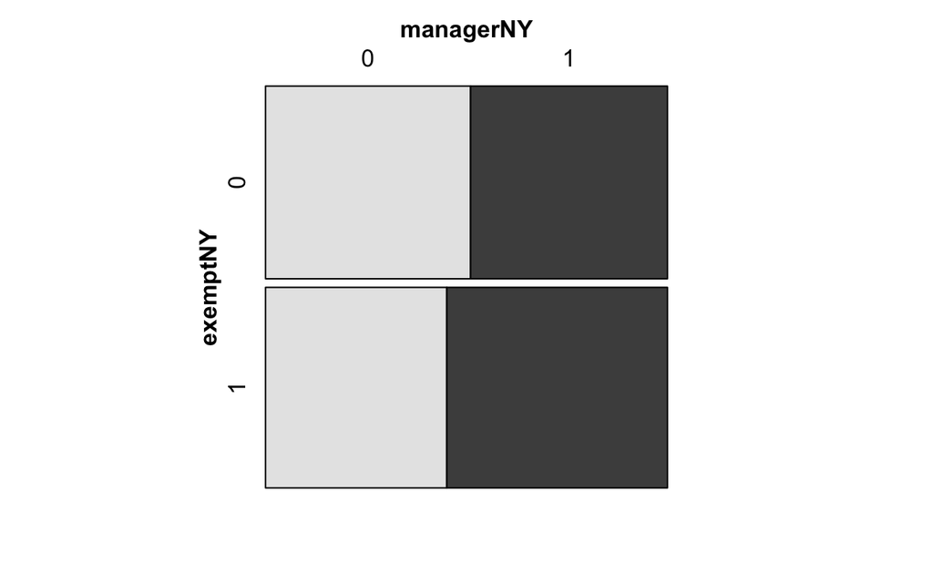

```r
library(vcd)

mosaic(managerNY ~ exemptNY, data = balanced)
```

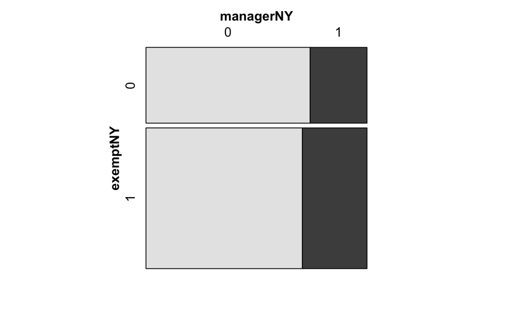

```r
mosaic(managerNY ~ exemptNY, data = unbalanced)
```

Association tables provide the Pearson residuals for independence.

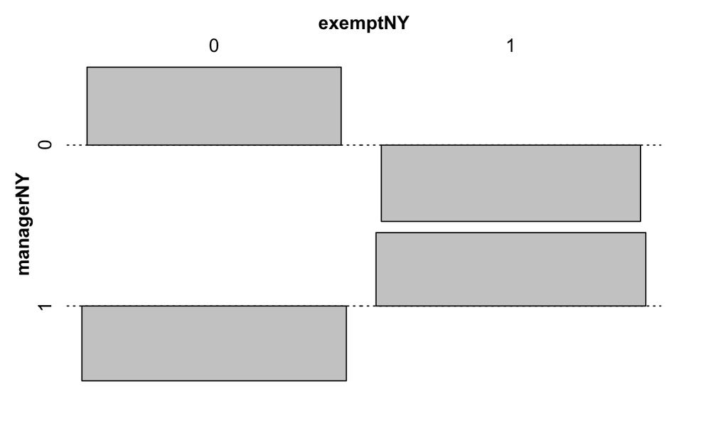

```r
assoc(table(balanced))
```

We will come back to this later.

The vcdExtra package (you will need to install rgl along with it) extends the functionality of vcd and let’s you create some interesting plots:

```r
library(vcdExtra)

library(dplyr)

mtcars %>%
  select(am, cyl, gear) %>%
  table %>%
  mosaic3d(., box = TRUE)
```

If you want to keep yourself firmly planted in the ggplot2 ecosystem, then you can use ggmosaic:

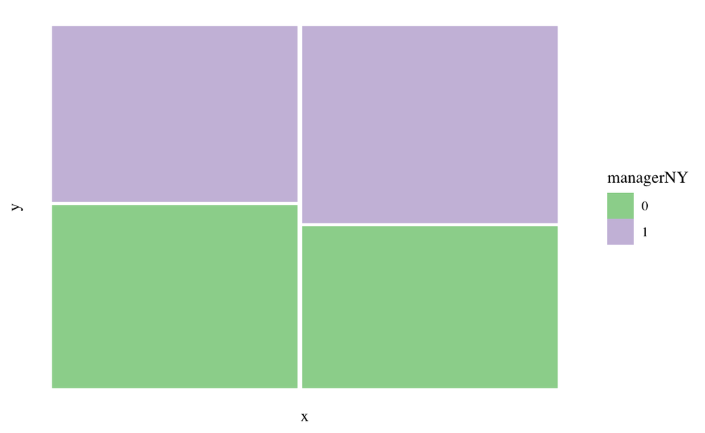

```r
library(ggmosaic)

library(dplyr)

balancedTableDF <- balanced %>%
  table() %>%
  as.data.frame()

ggplot(data = balancedTableDF) +
  geom_mosaic(aes(weight = Freq, x = product(exemptNY), fill = managerNY)) +
  ggthemes::theme_tufte() +
  scale_fill_brewer(type = "qual")
```

Some categorical data, especially in combinations, can be thought of as *sets* (i.e., a group of unique objects). Sets and their various brethren are cornerstones of math, but the visualization of those sets has largely been in the world of the Venn diagram. Venn diagrams are great for very small sets, but quickly fall apart when our sets become large. Venn diagrams also have larger issues with circles and proportional sizes.

```r
dataLink <- "http://www.nd.edu/~sberry5/data/teamMembershipData.csv"

teamMembership <- read.csv(dataLink)

knitr::kable(head(teamMembership))
```

| personID | team1 | team2 | team3 | team4 | team5 |
| --- | --- | --- | --- | --- | --- |
| 1 | 0 | 1 | 1 | 0 | 1 |
| 2 | 0 | 0 | 0 | 0 | 1 |
| 3 | 1 | 1 | 0 | 0 | 1 |
| 4 | 0 | 1 | 0 | 1 | 0 |
| 5 | 0 | 0 | 1 | 0 | 0 |
| 6 | 0 | 1 | 0 | 1 | 1 |

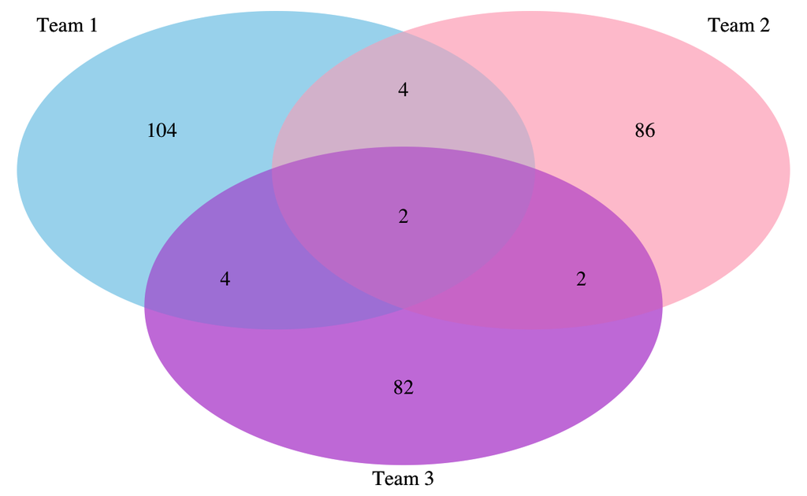

With different data, but with 5 groups (not that it matters):

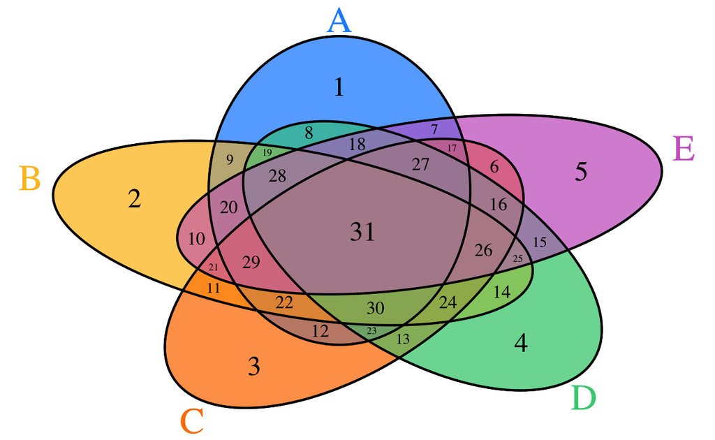

Instead, set plots have been created to provide better visual inspections of sets.

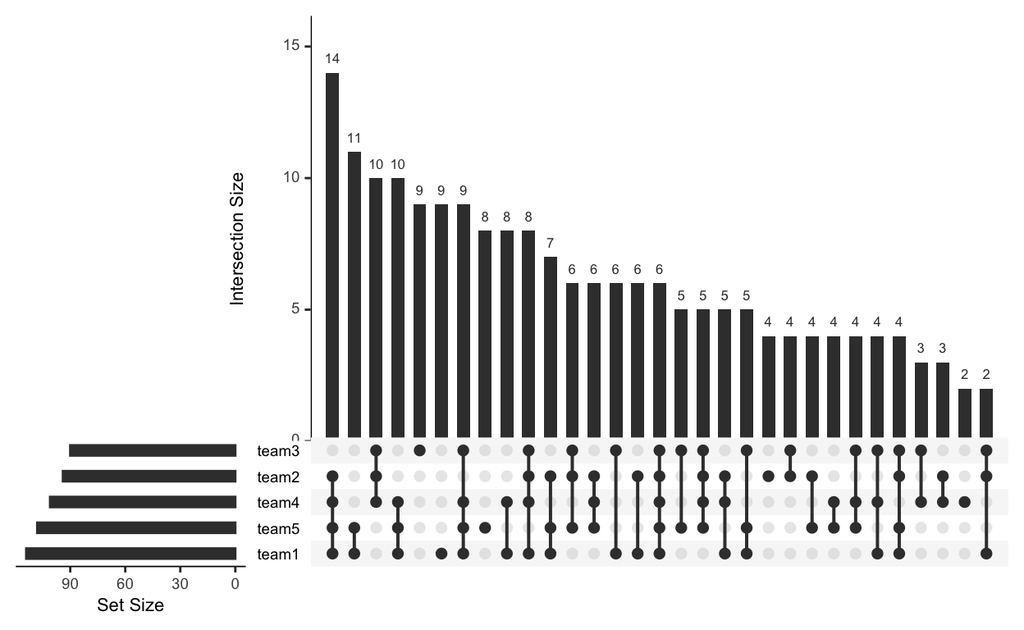

```r
library(UpSetR)

upset(teamMembership, order.by = "freq", empty.intersections = "on")
```

We have all the same information, but in an easier to digest format!

## Contingency Tables

The contingency table is the *insert plain, but high utility trope of your choice* worker behind many things. We previously saw what it could do with our visualizations, but it can be useful in its own right.

```r
contTable <- table(balanced)

contTable
```

```
         exemptNY
managerNY  0  1
        0 25 23
        1 24 28
```

Let’s not forget about this – we are going to be coming back to it soon.

## Association

When we are dealing with purely categorical variables, it is not *proper* to say correlation (it is not proper in the same way that it is not proper to wear white after Labor Day).

When we want to see the association between two categorical variables, we can use a few different techniques. The ones that you will most commonly see are Cramer’s *V* (also noted as $\phi_c$) and the $\phi$ coefficient. Cramer’s *V* is handy because it ranges from 0 (no association) to 1 (perfect association). The $\phi$ coefficient’s range will change based upon the distribution of the variables (but only if one of those variables has more than two categories).

$$V = \sqrt\frac{\chi^2/n}{min(c-1,r-1)}$$

$$\phi = \sqrt\frac{\chi^2}{n}$$

In the case of a 2 x 2 contingency table, both Cramer’s *V* and the $\phi$ coefficient will be the same (they will also be the same as our old friend Pearson’s *r*). An important consideration is that Cramer’s *V* can actually go up to 1, whereas the other values cannot.

A number of packages will run $\phi_c$ and $\phi$, but you can get them both through the assocstats function in vcd:

```r
summary(assocstats(table(balanced)))
```

```
Number of cases in table: 100
Number of factors: 2
Test for independence of all factors:
    Chisq = 0.3512, df = 1, p-value = 0.5535
                     X^2 df P(> X^2)
Likelihood Ratio 0.35135  1  0.55335
Pearson          0.35117  1  0.55345

Phi-Coefficient   : 0.059
Contingency Coeff.: 0.059
Cramer's V        : 0.059
```

The contingency coefficient is the square root of $\chi^2$ divided by $N + \chi^2$. It is only ever positive.

We can start to look at these values to decide whether there is association within our data or independence.

## $chi^2$

If we take our contingency table, we can continue to do some interesting things with it. One such thing is to figure out the expected proportion of each cell within our table.

We can compute our expected cell size as follows:

$$e = \frac{row.sum * column.sum}{grand.total}$$

With that, let’s take a look at our contingency table for the balanced data that we saw earlier:

```r
table(balanced)
```

```
         exemptNY
managerNY  0  1
        0 25 23
        1 24 28
```

We need the information about the margins to be able to compute the expected size, so let’s use the addmargins function:

```r
tabs <- addmargins(table(balanced))

tabs
```

```
         exemptNY
managerNY   0   1 Sum
      0    25  23  48
      1    24  28  52
      Sum  49  51 100
```

Let’s put all of these into individual objects. We could reference those rows with magic numbers (e.g., tabs[1, 1]) or something a little safer (but slightly verbose, because tables are silly to work on).

```r
nonManagerNonExemptObserved <- tabs[which(dimnames(tabs)$managerNY == "0"),
                                    which(dimnames(tabs)$exemptNY == "0")]

nonManagerExemptObserved <- tabs[which(dimnames(tabs)$managerNY == "0"),
                                    which(dimnames(tabs)$exemptNY == "1")]

managerNonExemptObserved <- tabs[which(dimnames(tabs)$managerNY == "1"),
                                    which(dimnames(tabs)$exemptNY == "0")]

managerExemptObserved <- tabs[which(dimnames(tabs)$managerNY == "1"),
                                    which(dimnames(tabs)$exemptNY == "1")]

row1Total <- tabs[which(dimnames(tabs)$managerNY == "0"),
                                    which(dimnames(tabs)$exemptNY == "Sum")]

row2Total <- tabs[which(dimnames(tabs)$managerNY == "1"),
                                    which(dimnames(tabs)$exemptNY == "Sum")]

column1Total <- tabs[which(dimnames(tabs)$managerNY == "Sum"),
                                    which(dimnames(tabs)$exemptNY == "0")]

column2Total <- tabs[which(dimnames(tabs)$managerNY == "Sum"),
                                    which(dimnames(tabs)$exemptNY == "1")]
```

We can start with non-manager (0) and non-exempt (0):

Note that the 100 here is our marginal total. We could have also used sum(table(balanced)).

```r
nonManagerNonExemptExpected <- (row1Total * column1Total) / 100

nonManagerNonExemptExpected
```

```
[1] 23.52
```

So the expected count for that particular cell is 23.52.

We can do the same for the remaining groups now:

```r
nonManagerExemptExpected <- (row1Total * column2Total) / 100

managerNonExemptExpected <- (row2Total * column1Total) / 100

managerExemptExpected <- (row2Total * column2Total) / 100
```

Now that we have the expected values for each of the 4 cells, we can use the $\chi^2$ test to see if our observed values are different from our expected values.

$$\chi^2 = \sum\frac{(o - e)^2}{e}$$

In a $\chi^2$ test, we take our expected frequencies and test them against our observed frequencies. If they are pretty close (i.e., our expected values are close to our observed values), we have a small $\chi^2$. In this small $\chi^2$, we are going to retain our null hypothesis (i.e., we fail to reject the null hypothesis that the variables are different).

$H_0 = \text{Variables A and B are independent}$

$H_1 = \text{Variables A and B are associated}$

In our null hypothesis, we are essentially saying that the variables are independent of each other – they are not associated.

```r
nonManNonEx <- (nonManagerNonExemptObserved - nonManagerNonExemptExpected)^2 /
  nonManagerNonExemptExpected

nonManEx  <- (nonManagerExemptObserved - nonManagerExemptExpected)^2 /
  nonManagerExemptExpected

manNonEx <- (managerNonExemptObserved - managerNonExemptExpected)^2 /
  managerNonExemptExpected

manEx <- (managerExemptObserved - managerExemptExpected)^2 /
  managerExemptExpected

chiSquareRes <- nonManNonEx + nonManEx + manNonEx + manEx

chiSquareRes
```

```
[1] 0.3511661
```

We can save all of that hassle and just use the `chisq.test` function.

```r
test <- chisq.test(balanced$exemptNY, balanced$managerNY, correct = FALSE)

test
```

```
    Pearson's Chi-squared test

data:  balanced$exemptNY and balanced$managerNY
X-squared = 0.35117, df = 1, p-value = 0.5535
```

In a $\chi^2$ test, we can use the *p*-value to tell us whether or not the rows and columns fit the expected distribution or are significantly associated. Given our small $\chi^2$ and our large *p*-value, we can be pretty certain that our rows and columns are not associated (which we have already seen in our association measures above) and the number expected versus the number observed are not significantly different.

### The Yates Correction

You might have noticed the correct = FALSE argument above. If we set that argument to TRUE, we are doing what is called Yate’s correction. Our contingency table has binomial frequencies with discreet probability. In our $\chi^2$ test, we are taking those binomial frequencies and applying them to a continuous $\chi^2$ distribution (the $\chi^2$ distribution is a distribution of *k* – meaning number of variables – sums of squares for normal variables). Yates found this to be tenuous, so subtracted .5 from the difference between expected and observed values.

```r
chisq.test(balanced$exemptNY, balanced$managerNY, correct = TRUE)
```

```
    Pearson's Chi-squared test with Yates' continuity correction

data:  balanced$exemptNY and balanced$managerNY
X-squared = 0.15397, df = 1, p-value = 0.6948
```

We can see that it shrunk our $\chi^2$ and increased our *p*-value. Most statistics behave differently with varying sample sizes – $\chi^2$ is no different. When sample sizes are small (what’s small – who knows), $\chi^2$ will have an increased chance of being significant.

### Exact Tests

Small samples cause problems for a variety of tests (we will learn about others later on). To help combat this problem, a family of *exact* tests come to help.

Exact tests provide exact *p*-values (or other test statistics), instead of approximations when the sample size gets large. The fisher.test function will get us our exact *p*-values.

```r
fisher.test(balanced$managerNY, balanced$exemptNY)
```

```
    Fisher's Exact Test for Count Data

data:  balanced$managerNY and balanced$exemptNY
p-value = 0.6891
alternative hypothesis: true odds ratio is not equal to 1
95 percent confidence interval:
 0.5373706 2.9966803
sample estimates:
odds ratio
  1.265087
```

You can see that we did not get a new $\chi^2$ value, but we did get a new *p*-value.

At the end of the day, though, you will not be likely to get much guff from just running a standard $\chi^2$ test.

Let’s see what would happen with our unbalanced data:

```r
unbalancedTest <- chisq.test(unbalanced$exemptNY, unbalanced$managerNY,
                             correct = FALSE)
```

Before we look at the results, let’s check a few things out:

```r
unbalancedTest$observed
```

```
                   unbalanced$managerNY
unbalanced$exemptNY  0  1
                  0 26  9
                  1 46 19
```

```r
unbalancedTest$expected
```

```
                   unbalanced$managerNY
unbalanced$exemptNY    0    1
                  0 25.2  9.8
                  1 46.8 18.2
```

Wow…what do you expect our $\chi^2$ value will be?

```r
unbalancedTest$statistic
```

```
X-squared
 0.139543
```

How about this one:

```r
shipCount <- as.table(rbind(c(762, 327, 468), c(484, 239, 477)))

dimnames(shipCount) <- list(shipType = c("Foreign", "Domestic"),
                    port = c("South Louisiana", "Houston", "Long Beach"))

shipCount
```

```
          port
shipType   South Louisiana Houston Long Beach
  Foreign              762     327        468
  Domestic             484     239        477
```

```r
shipChiSquare <- chisq.test(shipCount)
```

```r
shipChiSquare$expected
```

```
          port
shipType   South Louisiana  Houston Long Beach
  Foreign         703.6714 319.6453   533.6834
  Domestic        542.3286 246.3547   411.3166
```

How do you think our $\chi^2$ will look.

```r
shipChiSquare
```

```
    Pearson's Chi-squared test

data:  shipCount
X-squared = 30.07, df = 2, p-value = 2.954e-07
```

If you said, “Bigger”, you are correct.

Let’s look at our expected and observed again.

Expected:

```r
shipChiSquare$expected
```

```
          port
shipType   South Louisiana  Houston Long Beach
  Foreign         703.6714 319.6453   533.6834
  Domestic        542.3286 246.3547   411.3166
```

Observed:

```r
shipChiSquare$observed
```

```
          port
shipType   South Louisiana Houston Long Beach
  Foreign              762     327        468
  Domestic             484     239        477
```

Remember that our $\chi^2$ is looking at $observed - expected$ and then dividing by expected. If we take our $observed - expected$ and divide it by square root of expected counts, we get a signed value that we can use for plotting the *directional* associaiton for a particular cell.

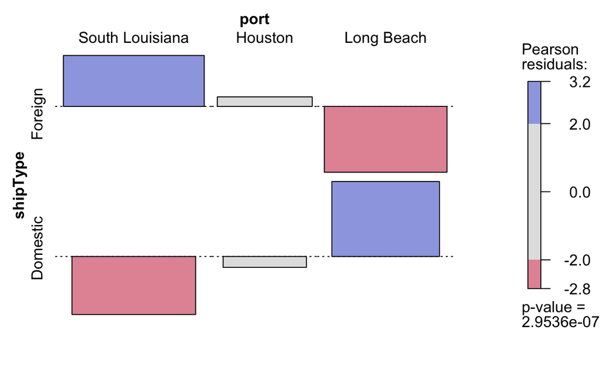

```r
assoc(shipCount, shade = TRUE)
```

We can see what we get, just by using our values for foreign and South Louisiana:

```r
(762 - 703.6714) / sqrt(703.6714)
```

```
[1] 2.198855
```

## The G-test

No statisticians is ever satisfied and people took exception to the $\chi^2$ because of one very important assumption that it makes: the marginal values for the rows and columns are random. The exact test has a different issue – all of the marginal values are fixed (would really only happen if you were doing experiments). Another big issue relates to size – $\chi^2$ can fall apart when you get cells under 5. That is where the G-test comes in:

$G = 2 \Sigma \, observed_i * ln \frac{observed_i}{expected_i}$

```r
2 * sum(
  shipChiSquare$observed * log(shipChiSquare$observed/shipChiSquare$expected)
)
```

```
[1] 30.01669
```

Will give us our G value – this will be nearly identical to what the GTest function will return, but will be more stable under most conditions:

```r
DescTools::GTest(shipCount)$expected
```

```
         South Louisiana  Houston Long Beach
Foreign         703.6714 319.6453   533.6834
Domestic        542.3286 246.3547   411.3166
```

Let’s see how it will work with some NBA data.

```r
load("allStars.RData")

DescTools::GTest(playerTable)
```

```
    Log likelihood ratio (G-test) test of independence without
    correction

data:  playerTable
G = 30.688, X-squared df = 4, p-value = 3.545e-06
```

We see that these variables do exhibit some dependence, but what would the direction look like?

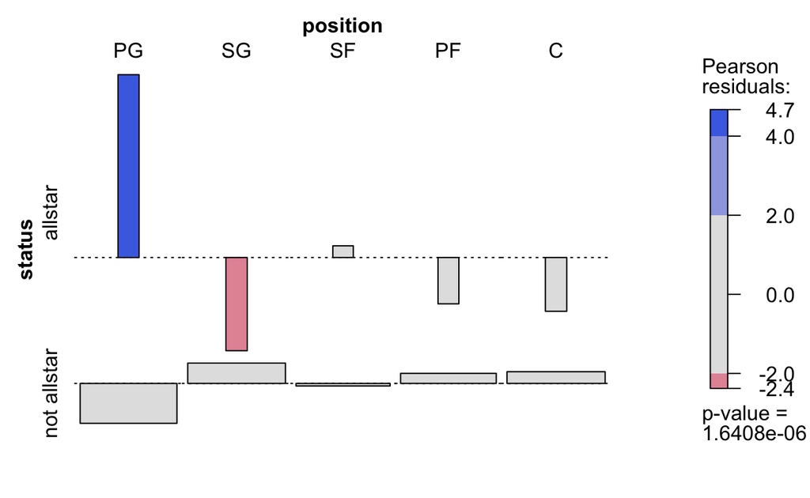

```r
assoc(playerTable, shade = TRUE)
```

## Practical Applications

Aircraft Carriers and Aircraft

Computational Engines (Tensorflow, Microsoft Cognitive Toolkit, Theano) and Languages (F#, R, Python, Scala)

D&D Character classes (fighting-man, magic-user, cleric) and races (human, elf, halfling)

Age Group and Media-type consumption

Political affiliation and region

## Extensions

We have just been looking at these models with 2 variables, but what if we want to throw a 3rd variable into the model – we could turn to the Cochran-Mantel-Haenszel test (think about mapping a decade variable into our All Star data). In reality, though, you might choose to think more about what question you are really asking if you are getting into a 3-way contingency table.